# Titanic Dataset

I have used kaggle dataset. you can download the dataset from this link :- https://www.kaggle.com/c/titanic/data . we will get 3 dataset test.csv, train.csv and gender_submission.csv.I have used train.csv to find the best model for this. Using test.csv we will predict and match our prediction with the attribute of gender_submission.csv for checking our accuracy.

Following are steps for :

```
1. Importing these dataset using python.
```

```python
import pandas as pd
test_df = pd.read_csv('test.csv')
train_df = pd.read_csv('train.csv')
```

Lets remove the warings

```python
import warnings
warnings.filterwarnings(action='ignore')
```

```python
pd.set_option('display.max_column',12,'display.width',1000)
print(test_df.head(4))
```

```
   PassengerId  Pclass                              Name     Sex   Age  SibSp  Parch  Ticket    Fare Cabin Embarked
0          892       3                  Kelly, Mr. James    male  34.5      0      0  330911  7.8292   NaN        Q
1          893       3  Wilkes, Mrs. James (Ellen Needs)  female  47.0      1      0  363272  7.0000   NaN        S
2          894       2         Myles, Mr. Thomas Francis    male  62.0      0      0  240276  9.6875   NaN        Q
3          895       3                  Wirz, Mr. Albert    male  27.0      0      0  315154  8.6625   NaN        S
```

```python
print(train_df.head(4))
```

```
   PassengerId  Survived  Pclass                                               Name     Sex   Age  SibSp  Parch            Ticket     Fare Cabin Embarked
0            1         0       3                            Braund, Mr. Owen Harris    male  22.0      1      0         A/5 21171   7.2500   NaN        S
1            2         1       1  Cumings, Mrs. John Bradley (Florence Briggs Th...  female  38.0      1      0          PC 17599  71.2833   C85        C
2            3         1       3                             Heikkinen, Miss. Laina  female  26.0      0      0  STON/O2. 3101282   7.9250   NaN        S
3            4         1       1       Futrelle, Mrs. Jacques Heath (Lily May Peel)  female  35.0      1      0            113803  53.1000  C123        S
```

## Data Preprocessing

1. Lets find if there is any null value in dataset of train.csv

```python
print(train_df.isna().sum())
```

```
PassengerId      0
Survived         0
Pclass           0
Name             0
Sex              0
Age            177
SibSp            0
Parch            0
Ticket           0
Fare             0
Cabin          687
Embarked         2
dtype: int64
```

And null value in test.csv dataset are:-

```python
print(test_df.isna().sum())
```

```
PassengerId      0
Pclass           0
Name             0
Sex              0
Age             86
SibSp            0
Parch            0
Ticket           0
Fare             1
Cabin          327
Embarked         0
dtype: int64
```

```python
print(test_df.shape)
print(train_df.shape)
```

```
(418, 11)
(891, 12)
```

```python
print(train_df.columns.values)
```

```
['PassengerId' 'Survived' 'Pclass' 'Name' 'Sex' 'Age' 'SibSp' 'Parch'
 'Ticket' 'Fare' 'Cabin' 'Embarked']
```

There are two classification :-

```
1. Servived and 2. notservived
```

```python
survived = 'survived'
not_survived = 'not survived'
```

Lets filter men and women in dataset

```python
women = train_df[train_df['Sex']=='female']
men = train_df[train_df['Sex']=='male']
```

## Data Dictionary :-

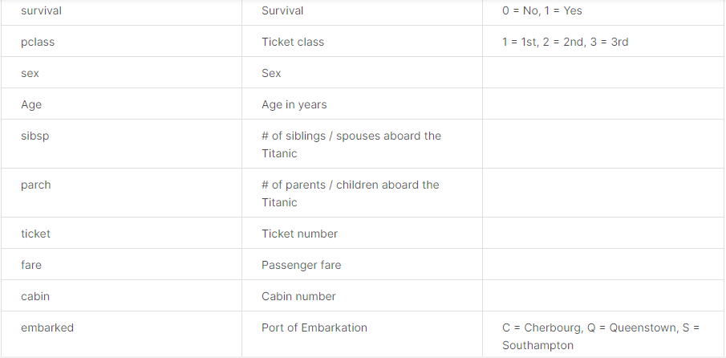

```python
from IPython.display import Image
Image(filename="detail.png")
```

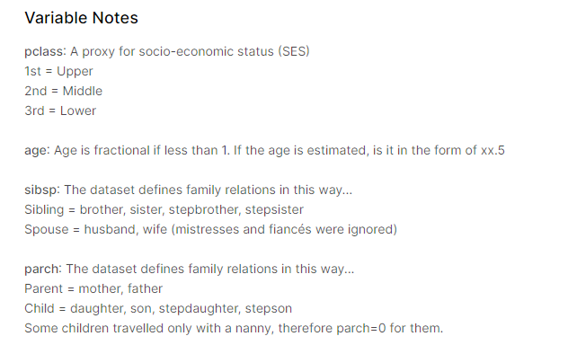

```python
Image(filename="variable.png")
```

Now lets see if there is any realtion in pclass and age usng boxplot by looking on outliers

```python
import seaborn as sns
from matplotlib import pyplot as plt
```

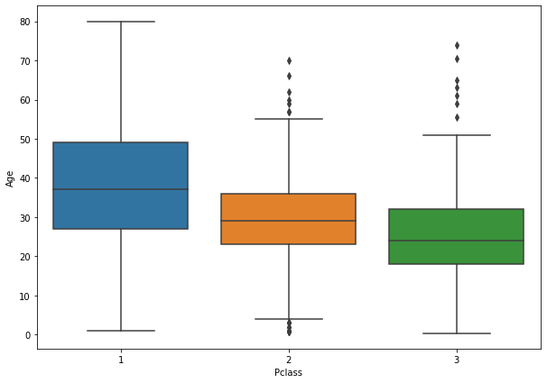

```python
plt.figure(figsize=(10,7))
sns.boxplot(x='Pclass',y= 'Age', data=train_df)
plt.show()
```

By graph we can conclude that there is relationship between pclass and age as there are very few outliers. Now lets see realtionship for servived people accourding to their age.

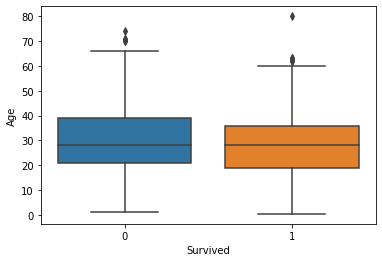

```python
sns.boxplot(x='Survived',y= 'Age',data= train_df)
plt.show()
```

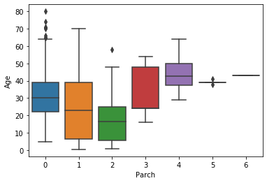

```python
sns.boxplot(x='Parch',y='Age',data=train_df)
plt.show()
```

Not fully depend but there is some relation between parch and age. lets see any relation in age and sex.

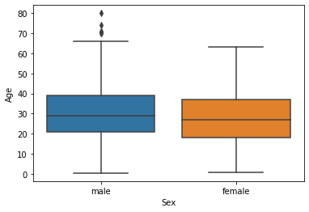

```python
sns.boxplot(x='Sex',y='Age',data=train_df)
plt.show()
```

Lets remove passanger id its not for our use

```python
train_df.pop('PassengerId')
```

```
0        1
1        2
2        3
3        4
4        5
      ...
886    887
887    888
888    889
889    890
890    891
Name: PassengerId, Length: 891, dtype: int64
```

```python
sex_group = train_df.groupby(['Pclass','Sex']).mean()
print(sex_group)
```

```
               Survived        Age     SibSp     Parch        Fare
Pclass Sex
1      female  0.968085  34.611765  0.553191  0.457447  106.125798
       male    0.368852  41.281386  0.311475  0.278689   67.226127
2      female  0.921053  28.722973  0.486842  0.605263   21.970121
       male    0.157407  30.740707  0.342593  0.222222   19.741782
3      female  0.500000  21.750000  0.895833  0.798611   16.118810
       male    0.135447  26.507589  0.498559  0.224784   12.661633
```

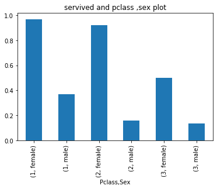

```python
sex_group['Survived'].plot.bar()
plt.title("servived and pclass ,sex plot")
plt.show()
```

```python
import numpy as np
group_by_age = pd.cut(train_df['Age'], np.arange(0,100,10))
age_group = train_df.groupby(group_by_age).mean()
print(age_group)
```

```
          Survived    Pclass        Age     SibSp     Parch       Fare
Age
(0, 10]   0.593750  2.640625   4.268281  1.843750  1.421875  30.434439
(10, 20]  0.382609  2.530435  17.317391  0.591304  0.391304  29.529531
(20, 30]  0.365217  2.386957  25.423913  0.321739  0.239130  28.306719
(30, 40]  0.445161  2.090323  35.051613  0.374194  0.393548  42.496100
(40, 50]  0.383721  1.918605  45.372093  0.372093  0.430233  41.163181
(50, 60]  0.404762  1.523810  54.892857  0.309524  0.309524  44.774802
(60, 70]  0.235294  1.529412  63.882353  0.176471  0.352941  45.910782
(70, 80]  0.200000  1.800000  73.300000  0.000000  0.000000  25.936680
(80, 90]       NaN       NaN        NaN       NaN       NaN        NaN
```

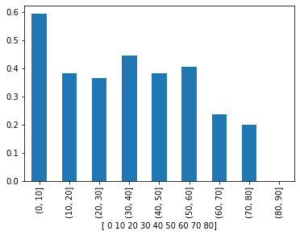

```python
age_group['Survived'].plot.bar()
plt.xlabel(np.arange(0,90,10))
plt.show()
```

lets remove name ticket and cabine it's not usable.

```python
train_df=train_df.drop(['Name','Ticket','Cabin'],axis=1)
print(train_df.head(3))
```

```
   Survived  Pclass     Sex   Age  SibSp  Parch     Fare Embarked
0         0       3    male  22.0      1      0   7.2500        S
1         1       1  female  38.0      1      0  71.2833        C
2         1       3  female  26.0      0      0   7.9250        S
```

Now lets make our dataset for fiting in module. I am performing this operation

```python
train_df['Embarked']= train_df['Embarked'].fillna(method = 'pad')
train_df['Age'] = train_df['Age'].fillna(method='bfill')
print("na is :- \n",train_df.isna().sum())
```

```
na is :-
 Survived    0
Pclass      0
Sex         0
Age         0
SibSp       0
Parch       0
Fare        0
Embarked    0
dtype: int64
```

Encoding sex as male:-1 femail:- 0

```python
from sklearn.preprocessing import LabelEncoder
labelencoder = LabelEncoder()
train_df.Sex = labelencoder.fit_transform(train_df.Sex)
print(train_df.head(3))
```

```
   Survived  Pclass  Sex   Age  SibSp  Parch     Fare Embarked
0         0       3    1  22.0      1      0   7.2500        S
1         1       1    0  38.0      1      0  71.2833        C
2         1       3    0  26.0      0      0   7.9250        S
```

```python
print(train_df['Embarked'].unique())
```

```
['S' 'C' 'Q']
```

encoding s:- 0,0,1 c:- 1,0,0 q:- 0,1,0

```python
dummies_data = pd.get_dummies(train_df.Embarked)
print(dummies_data)
```

```
     C  Q  S
0    0  0  1
1    1  0  0
2    0  0  1
3    0  0  1
4    0  0  1
..  .. .. ..
886  0  0  1
887  0  0  1
888  0  0  1
889  1  0  0
890  0  1  0

[891 rows x 3 columns]
```

```python
df = pd.concat([train_df,dummies_data],axis=1)
df.pop('Embarked')
print(df.head(2))
```

```
   Survived  Pclass  Sex   Age  SibSp  Parch     Fare  C  Q  S
0         0       3    1  22.0      1      0   7.2500  0  0  1
1         1       1    0  38.0      1      0  71.2833  1  0  0
```

now breaking the data as:-

```
x= feature data and y= taget data
```

```python
x= df.iloc[:,1:9].values
y = df.iloc[:,0].values
```

```python
print(x)
print(y)
```

```
[[ 3.      1.     22.     ...  7.25    0.      0.    ]
 [ 1.      0.     38.     ... 71.2833  1.      0.    ]
 [ 3.      0.     26.     ...  7.925   0.      0.    ]
 ...
 [ 3.      0.     26.     ... 23.45    0.      0.    ]
 [ 1.      1.     26.     ... 30.      1.      0.    ]
 [ 3.      1.     32.     ...  7.75    0.      1.    ]]
[0 1 1 1 0 0 0 0 1 1 1 1 0 0 0 1 0 1 0 1 0 1 1 1 0 1 0 0 1 0 0 1 1 0 0 0 1
 0 0 1 0 0 0 1 1 0 0 1 0 0 0 0 1 1 0 1 1 0 1 0 0 1 0 0 0 1 1 0 1 0 0 0 0 0
 1 0 0 0 1 1 0 1 1 0 1 1 0 0 1 0 0 0 0 0 0 0 0 1 1 0 0 0 0 0 0 0 1 1 0 1 0
 0 0 0 0 0 0 0 0 0 0 0 0 1 0 1 0 1 1 0 0 0 0 1 0 0 1 0 0 0 0 1 1 0 0 0 1 0
 0 0 0 1 0 0 0 0 1 0 0 0 0 1 0 0 0 1 1 0 0 0 0 0 1 0 0 0 0 0 0 0 0 0 0 1 1
 0 1 1 0 0 1 0 1 1 1 1 0 0 1 0 0 0 0 0 1 0 0 1 1 1 0 1 0 0 0 1 1 0 1 0 1 0
 0 0 1 0 1 0 0 0 1 0 0 1 0 0 0 1 0 0 0 1 0 0 0 0 0 1 1 0 0 0 0 0 0 1 1 1 1
 1 0 1 0 0 0 0 0 1 1 1 0 1 1 0 1 1 0 0 0 1 0 0 0 1 0 0 1 0 1 1 1 1 0 0 0 0
```

[output cut: 17 more lines]

Lets Check the score of feature ahter performing these actions.

```python
from sklearn.ensemble import ExtraTreesClassifier
classifier = ExtraTreesClassifier()
classifier.fit(x,y)
score = classifier.feature_importances_
print("Score: ",score)
```

```
Score:  [0.10172063 0.28071608 0.2600257  0.04634036 0.046022   0.23228098
 0.02033058 0.01256366]
```

from freatur classifier we can say that we need to keep all data.

now rescalling the dataset

```python
from sklearn.preprocessing import StandardScaler
scale = StandardScaler()
rescaled_x = scale.fit_transform(x)
```

spriting the main data to train test without rescaling

```python
from sklearn.model_selection import train_test_split
x_train,x_test,y_train,y_test = train_test_split(x,y,test_size=0.3,random_state=7)
```

spriting the data after recalling it

```python
x1_train,x1_test,y1_train,y1_test = train_test_split(rescaled_x,y,test_size=0.3,random_state=7)
```